# Pertemuan 3 - Regresi dengan Peubah Lag

Vita Rizkyana Anggraeni_G1401211065

## Input Data

Peubah dependen (Y): AQI Peubah independen (X): o3

```r
data <- import("https://raw.githubusercontent.com/vitaarizkyana/PraktikumMPDW/main/Pertemuan%203/Data%20Pertemuan%203.csv")
Yt <- data$AQI #Peubah respon
Xt <- data$o3 #Peubah penjelas
data <- data.frame(Yt,Xt)
View(data)
summary(data)
```

```
##        Yt              Xt
##  Min.   :19.00   Min.   :41.48
##  1st Qu.:25.00   1st Qu.:53.64
##  Median :27.00   Median :57.22
##  Mean   :26.18   Mean   :56.57
##  3rd Qu.:28.00   3rd Qu.:60.08
##  Max.   :32.00   Max.   :68.66
```

```r
str(data)
```

```
## 'data.frame':    72 obs. of  2 variables:
##  $ Yt: num  30.2 28.2 26.6 25 26 26 26 24 23 24 ...
##  $ Xt: num  55.8 54.9 54.6 55.1 55.8 ...
```

## Pembagian Data

```r
#Split Data
train<-data[1:57,] # data training berisi 80% data pertama
test<-data[58:72,] # data testing berisi 20% data sisanya
```

## Mengubah data menjadi data time series

```r
#data time series
train.ts<-ts(train)
test.ts<-ts(test)
data.ts<-ts(data)
```

## Model Koyck

Model Koyck didasarkan pada asumsi bahwa semakin jauh jarak lag peubah independen dari periode sekarang maka semakin kecil pengaruh peubah lag terhadap peubah dependen.

Koyck mengusulkan suatu metode untuk menduga model dinamis distributed lag dengan mengasumsikan bahwa semua koefisien $\beta$ mempunyai tanda sama.

Model koyck merupakan jenis paling umum dari model infinite distributed lag dan juga dikenal sebagai geometric lag

$$y_t=a(1-\lambda)+\beta_0X_t+\beta_1Z_t+\lambda Y_{t-1}+V_t$$

dengan
$$V_t=u_t-\lambda
u_{t-1}$$

### Pemodelan

Fungsi `koyckDlm()` akan menerapkan model lag terdistribusi dengan transformasi Koyck satu prediktor. Nilai `x` dan `y` tidak perlu sebagai objek *time series* (`ts`). `intercept` dapat dibuat `TRUE` untuk memasukkan intersep ke dalam model.

```r
#MODEL KOYCK
#koyckDlm(x , y , intercept)
model.koyck <- koyckDlm(x = train$Xt, y = train$Yt)
summary(model.koyck)
```

```
##
## Call:
## "Y ~ (Intercept) + Y.1 + X.t"
##
## Residuals:
##       Min        1Q    Median        3Q       Max
## -1.127670 -0.301407  0.001002  0.262601  1.103471
##
## Coefficients:
##             Estimate Std. Error t value Pr(>|t|)
## (Intercept)  0.54798    0.92878   0.590    0.558
## Y.1          0.41955    0.08223   5.102 4.63e-06 ***
## X.t          0.25830    0.04107   6.289 6.25e-08 ***
## ---
## Signif. codes:  0 '***' 0.001 '**' 0.01 '*' 0.05 '.' 0.1 ' ' 1
##
## Residual standard error: 0.5053 on 53 degrees of freedom
## Multiple R-Squared: 0.9463,  Adjusted R-squared: 0.9443
## Wald test: 423.7 on 2 and 53 DF,  p-value: < 2.2e-16
##
## Diagnostic tests:
## NULL
##
##                             alpha      beta       phi
## Geometric coefficients:  0.944071 0.2582957 0.4195528
```

Dari hasil tersebut, didapat bahwa peubah $x_t$ dan $y_{t-1}$ memiliki nilai $P-Value < 0.05$. Hal ini menunjukkan bahwa peubah $x_t$ dan $y_{t-1}$ berpengaruh signifikan terhadap $y$ sehingga dapat disimpulkan bahwa peubah dependen AQI saat ini dipengaruhi oleh kandungan $O_3$ pada saat ini, serta nilai AQI satu hari sebelumnya. Adapun model keseluruhannya adalah sebagai berikut

$$\hat{y_t}=0.54798+0.25830X_t+0.41955Y_{t-1}$$
### Peramalan dan Akurasi

Berikut adalah hasil peramalan nilai AQI untuk 15 periode kedepan menggunakan model koyck

```r
#h =15, merupakan 15 periode yang akan diprediksi selanjutnya
fore.koyck <- forecast(model = model.koyck, x=test$Xt, h=15)
fore.koyck
```

```
## $forecasts
##  [1] 24.15387 23.05989 21.95429 21.12094 20.21706 19.74546 20.00947 20.67448
##  [9] 20.95348 21.07054 21.58152 23.08914 24.83015 26.29958 27.28558
##
## $call
## forecast.koyckDlm(model = model.koyck, x = test$Xt, h = 15)
##
## attr(,"class")
## [1] "forecast.koyckDlm" "dLagM"
```

```r
#Akurasi data testing
mape.koyck <- MAPE(fore.koyck$forecasts, test$Yt)

#Akurasi data training
mape.koyck.train <- GoF(model.koyck)["MAPE"]

c("MAPE Testing"=mape.koyck,"MAPE Training"=mape.koyck.train)
```

```
## $`MAPE Testing`
## [1] 0.03187326
##
## $`MAPE Training.MAPE`
## [1] 0.01435646
```

Berdasarkan akurasi di atas, terlihat bahwa nilai MAPE keduanya tidak jauh berbeda. Artinya, model regresi dengan distribusi lag ini tidak `overfitted` atau `underfitted`

## Regression with Distributed Lag

### Lag Optimum

```r
#Penentuan Lag Optimum
#dlm(formula , data , x , y , q , remove )
finiteDLMauto(formula = Yt ~ Xt,
              data = data.frame(train),
              model.type = "dlm", error.type = "AIC")
```

```
##    q - k    MASE      AIC      BIC    GMRAE   MBRAE R.Adj.Sq Ljung-Box
## 10    10 0.35051 22.97129 47.02321 14499.82 0.49589  0.98302  0.354745
```

Diperoleh lag optimum untuk peubah $O_3$ adalah 10 hari sebelumnya. Selanjutnya dilakukan pemodelan kembali dengan $q=10$

### Peramalan dan Akurasi Model DLM (Distribution Lag Model)

```r
#model dlm dengan lag optimum
model.dlm <- dlm(x = train$Xt,y = train$Yt , q = 10) #nilai q diganti dengan lag optimum yang diperoleh pada langkah sebelumnya
summary(model.dlm)
```

```
##
## Call:
## lm(formula = model.formula, data = design)
##
## Residuals:
##     Min      1Q  Median      3Q     Max
## -0.5204 -0.1663  0.0356  0.1624  0.5130
##
## Coefficients:
##              Estimate Std. Error t value Pr(>|t|)
## (Intercept) -0.294780   0.931786  -0.316  0.75361
## x.t          0.405638   0.063702   6.368 2.54e-07 ***
## x.1          0.159000   0.133129   1.194  0.24038
## x.2         -0.052741   0.126788  -0.416  0.67997
## x.3         -0.148621   0.121282  -1.225  0.22860
## x.4          0.143544   0.124404   1.154  0.25638
## x.5         -0.007047   0.123348  -0.057  0.95476
## x.6         -0.127683   0.123191  -1.036  0.30709
## x.7          0.287823   0.121937   2.360  0.02396 *
## x.8         -0.399437   0.121443  -3.289  0.00230 **
## x.9          0.304147   0.103813   2.930  0.00594 **
## x.10        -0.098958   0.048025  -2.061  0.04684 *
## ---
## Signif. codes:  0 '***' 0.001 '**' 0.01 '*' 0.05 '.' 0.1 ' ' 1
##
## Residual standard error: 0.2715 on 35 degrees of freedom
## Multiple R-squared:  0.9871, Adjusted R-squared:  0.983
## F-statistic: 243.1 on 11 and 35 DF,  p-value: < 2.2e-16
##
## AIC and BIC values for the model:
##        AIC      BIC
## 1 22.97129 47.02321
```

Dari hasil tersebut terdapat beberapa peubah yang berpengaruh signifikan terhadap taraf nyata 10% yaitu $x_t$ , $x_{t-7}$ , $x_{t-8}$ , $x_{t-9}$, dan $x_{t-10}$. Artinya, menurut model DLM dengan $q=10$, nilai AQI saat ini dipengaruhi oleh kandungan $O_3$ pada saat ini, 7 hari sebelumnya, 8 hari sebelumnya, 9 hari sebelumnya, dan 10 hari sebelumnya. Adapun keseluruhan model yang terbentuk adalah

$$\hat{Y_t}=-0.294780 + 0.405638X_t+0.159000x_{t-1}-...-0.098958X_{t-10}$$
Hasil peramalan 15 periode kedepan menggunakan model tersebut adalah sebagai berikut

```r
#peramalan dan akurasi
fore.dlm <- forecast(model = model.dlm, x=test$Xt, h=15)

#akurasi data testing
mape.dlm <- MAPE(fore.dlm$forecasts, test$Yt)

#akurasi data training
mape.dlm.train = GoF(model.dlm)["MAPE"]

c("MAPE Testing"=mape.dlm,"MAPE Training"=mape.dlm.train)
```

```
## $`MAPE Testing`
## [1] 0.01274404
##
## $`MAPE Training.MAPE`
## [1] 0.007238929
```

Berdasarkan akurasi di atas, terlihat bahwa nilai MAPE keduanya tidak jauh berbeda. Artinya, model regresi dengan distribusi lag ini tidak `overfitted` atau `underfitted`

## Model Autoregressive Distributed Lag (ARDL)

Peubah dependen dipengaruhi oleh peubah independen pada waktu sekarang, serta dipengaruhi juga oleh peubah dependen itu sendiri pada satu waktu yang lalu maka model tersebut disebut *autoregressive* (Gujarati 2004).

### Lag Optimum untuk ARDL

```r
#penentuan lag optimum
#ardlDlm(formula = NULL , data = NULL , x = NULL , y = NULL , p = 1 , q = 1 ,              remove = NULL )
model.ardl.opt <- ardlBoundOrders(data = data.frame(data), ic = "AIC",
                                  formula = Yt ~ Xt )
min_p=c()
for(i in 1:15){
  min_p[i]=min(model.ardl.opt$Stat.table[[i]])
}
q_opt=which(min_p==min(min_p, na.rm = TRUE))
p_opt=which(model.ardl.opt$Stat.table[[q_opt]] ==
              min(model.ardl.opt$Stat.table[[q_opt]], na.rm = TRUE))
data.frame("q_optimum" = q_opt, "p_optimum" = p_opt,
           "AIC"=model.ardl.opt$min.Stat)
```

```
##   q_optimum p_optimum      AIC
## 1         2        13 16.55044
```

Dapat terlihat bahwa nilai AIC terendah didapat ketika $p=13$ dan $q=2$, yaitu sebesar `16.55044`. Artinya, model autoregressive optimum didapat ketika $p=13$ dan $q=2$. Selanjutnya nilai ini akan dimasukkan ke dalam proses pembentukan model ardl.

```r
model.ardl <- ardlDlm(x = train$Xt, y = train$Yt, p = 13 , q = 2)
summary(model.ardl)
```

```
##
## Time series regression with "ts" data:
## Start = 14, End = 57
##
## Call:
## dynlm(formula = as.formula(model.text), data = data, start = 1)
##
## Residuals:
##      Min       1Q   Median       3Q      Max
## -0.45939 -0.19244  0.04237  0.18424  0.45823
##
## Coefficients:
##             Estimate Std. Error t value Pr(>|t|)
## (Intercept) -0.77136    1.12356  -0.687   0.4982
## X.t          0.39407    0.07142   5.517 7.61e-06 ***
## X.1          0.20786    0.18280   1.137   0.2655
## X.2         -0.02966    0.21795  -0.136   0.8928
## X.3         -0.13619    0.16006  -0.851   0.4023
## X.4          0.05226    0.16212   0.322   0.7497
## X.5          0.04957    0.14512   0.342   0.7353
## X.6         -0.13909    0.13618  -1.021   0.3162
## X.7          0.27019    0.13651   1.979   0.0581 .
## X.8         -0.31492    0.14669  -2.147   0.0409 *
## X.9          0.15294    0.16112   0.949   0.3509
## X.10         0.09506    0.16928   0.562   0.5790
## X.11        -0.16098    0.15567  -1.034   0.3103
## X.12         0.04585    0.12175   0.377   0.7094
## X.13         0.01492    0.05471   0.273   0.7871
## Y.1         -0.12772    0.19313  -0.661   0.5140
## Y.2          0.06633    0.21010   0.316   0.7546
## ---
## Signif. codes:  0 '***' 0.001 '**' 0.01 '*' 0.05 '.' 0.1 ' ' 1
##
## Residual standard error: 0.2868 on 27 degrees of freedom
## Multiple R-squared:  0.9884, Adjusted R-squared:  0.9814
## F-statistic: 143.2 on 16 and 27 DF,  p-value: < 2.2e-16
```

Terdapat 2 peubah yang berpengaruh signifikan terhadap nilai $AQI$ pada selang kepercayaan 95% yaitu $X_t$ dan $X_{t-8}$. Artinya, menurut model ARDL dengan $p=13$ dan $q=2$, nilai AQI saat ini dipengaruhi oleh kandungan $O_3$ pada saat ini, serta 8 hari sebelumnya. Model keseluruhannya adalah sebagai berikut:

$$\hat{Y}=-0.77136+ 0.39407X_t+0.20786
X_{t-1}+...-0.12772Y_{t-1}+0.06633Y_{t-2}$$

### Peramalan dan Akurasi Model ARDL

```r
fore.ardl <- forecast(model = model.ardl, x=test$Xt, h=15)
fore.ardl
```

```
## $forecasts
##  [1] 23.31655 21.80904 20.61682 20.06357 19.24186 18.82466 19.48054 20.86204
##  [9] 21.19795 20.60591 21.49901 23.57998 26.28620 27.75765 28.02269
##
## $call
## forecast.ardlDlm(model = model.ardl, x = test$Xt, h = 15)
##
## attr(,"class")
## [1] "forecast.ardlDlm" "dLagM"
```

```r
#akurasi data testing
mape.ardl <- MAPE(fore.ardl$forecasts, test$Yt)

#akurasi data training
mape.ardl.train <- GoF(model.ardl)["MAPE"]

c("MAPE Testing"=mape.ardl,"MAPE Training"=mape.ardl.train)
```

```
## $`MAPE Testing`
## [1] 0.01378089
##
## $`MAPE Training.MAPE`
## [1] 0.007069452
```

Berdasarkan akurasi di atas, terlihat bahwa nilai MAPE keduanya tidak jauh berbeda. Artinya, model regresi dengan distribusi lag ini tidak `overfitted` atau `underfitted`

## Perbandingan Model

```r
akurasi <- matrix(c(mape.koyck, mape.dlm, mape.ardl))
row.names(akurasi)<- c("Koyck","DLM","Autoregressive")
colnames(akurasi) <- c("MAPE")
akurasi
```

```
##                      MAPE
## Koyck          0.03187326
## DLM            0.01274404
## Autoregressive 0.01378089
```

Berdasarkan nilai MAPE, model paling optimum didapat pada *Model DLM* karena memiliki nilai MAPE yang terkecil dibandingkan *Model Koyck* dan *Model ARDL*.

### Plot

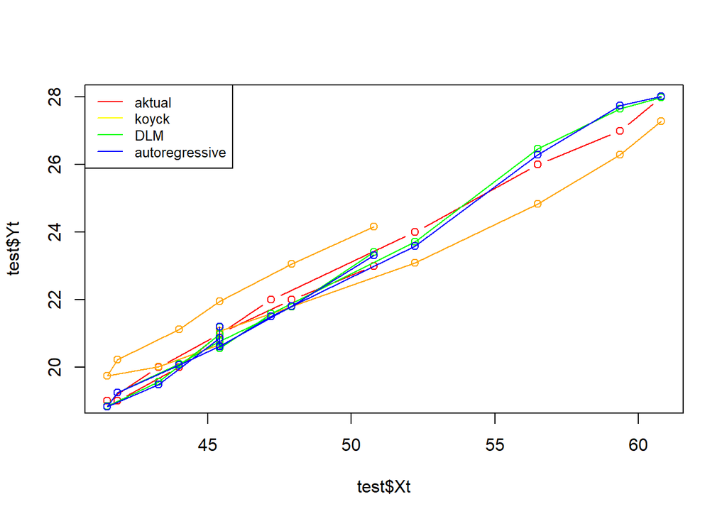

```r
par(mfrow=c(1,1))
plot(test$Xt, test$Yt, type="b", col="red")
points(test$Xt, fore.koyck$forecasts,col="orange")
lines(test$Xt, fore.koyck$forecasts,col="orange")
points(test$Xt, fore.dlm$forecasts,col="green")
lines(test$Xt, fore.dlm$forecasts,col="green")
points(test$Xt, fore.ardl$forecasts,col="blue")
lines(test$Xt, fore.ardl$forecasts,col="blue")
legend("topleft",c("aktual", "koyck","DLM", "autoregressive"), lty=1, col=c("red","yellow","green","blue"), cex=0.8)
```

Berdasarkan plot tersebut, terlihat bahwa plot yang paling mendekati data aktualnya adalah Model DLM 1, sehingga dapat disimpulkan model terbaik dalam hal ini adalah model regresi DLM 1.